# Tidy Tuesday 13 Feb 2024

COMP/STAT 112

2024-02-28

# Valentine’s Day Consumer Data

Happy Valentine’s Day! This week we’re exploring [Valentine’s Day survey data](https://www.kaggle.com/datasets/infinator/happy-valentines-day-2022). The National Retail Federation in the United States conducts surveys and has created a [Valentine’s Day Data Center](https://nrf.com/research-insights/holiday-data-and-trends/valentines-day/valentines-day-data-center) so you can explore the data on how consumers celebrate.

> The NRF has surveyed consumers about how they plan to celebrate Valentine’s Day annually for over a decade. Take a deeper dive into the data from the last 10 years, and use the interactive charts to explore a demographic breakdown of total spending, average spending, types of gifts planned and spending per type of gift.

The NRF has continued to collect data. The data for this week is from 2010 to 2022, as organized by Suraj Das for a Kaggle dataset. In the historical surveys gender was collected as only ‘Men’ and ‘Women’, which does not accurately include all genders.

If you’re looking for other Valentine’s Day type datasets, check out previous datasets on [chocolate](https://github.com/rfordatascience/tidytuesday/tree/master/data/2022/2022-01-18) or [board games](https://github.com/rfordatascience/tidytuesday/tree/master/data/2022/2022-01-25) (a good Valentine’s Day activity!).

## The Data

```r
# load in packages

library(tidyverse)

historical_spending<-read_csv("https://raw.githubusercontent.com/djoloughlin/tidytuesday2_13_2024/main/historical_spending")

gifts_gender<-read_csv("https://raw.githubusercontent.com/djoloughlin/tidytuesday2_13_2024/main/gifts_gender")

gifts_age<-read_csv("https://raw.githubusercontent.com/djoloughlin/tidytuesday2_13_2024/main/gifts_age")
```

```r
str(historical_spending)
```

```
## spc_tbl_ [13 × 10] (S3: spec_tbl_df/tbl_df/tbl/data.frame)
##  $ Year              : num [1:13] 2010 2011 2012 2013 2014 ...
##  $ PercentCelebrating: num [1:13] 60 58 59 60 54 55 55 54 55 51 ...
##  $ PerPerson         : num [1:13] 103 116 126 131 134 ...
##  $ Candy             : num [1:13] 8.6 10.8 10.8 11.6 10.8 ...
##  $ Flowers           : num [1:13] 12.3 12.6 13.5 13.5 15 ...
##  $ Jewelry           : num [1:13] 21.5 26.2 29.6 30.9 30.6 ...
##  $ GreetingCards     : num [1:13] 5.91 8.09 6.93 8.32 7.97 7.87 8.52 7.36 6.55 7.31 ...
##  $ EveningOut        : num [1:13] 23.8 24.9 25.7 27.9 27.5 ...
##  $ Clothing          : num [1:13] 10.9 12 10.4 11.5 13.4 ...
##  $ GiftCards         : num [1:13] 8.42 11.21 8.43 10.23 9 ...
##  - attr(*, "spec")=
##   .. cols(
##   ..   Year = col_double(),
##   ..   PercentCelebrating = col_double(),
##   ..   PerPerson = col_double(),
##   ..   Candy = col_double(),
##   ..   Flowers = col_double(),
##   ..   Jewelry = col_double(),
##   ..   GreetingCards = col_double(),
##   ..   EveningOut = col_double(),
##   ..   Clothing = col_double(),
##   ..   GiftCards = col_double()
##   .. )
##  - attr(*, "problems")=<externalptr>
```

```r
str(gifts_gender)
```

```
## spc_tbl_ [2 × 9] (S3: spec_tbl_df/tbl_df/tbl/data.frame)
##  $ Gender             : chr [1:2] "Men" "Women"
##  $ SpendingCelebrating: num [1:2] 27 27
##  $ Candy              : num [1:2] 52 59
##  $ Flowers            : num [1:2] 56 19
##  $ Jewelry            : num [1:2] 30 14
##  $ GreetingCards      : num [1:2] 37 43
##  $ EveningOut         : num [1:2] 33 29
##  $ Clothing           : num [1:2] 20 24
##  $ GiftCards          : num [1:2] 18 24
##  - attr(*, "spec")=
##   .. cols(
##   ..   Gender = col_character(),
##   ..   SpendingCelebrating = col_double(),
##   ..   Candy = col_double(),
##   ..   Flowers = col_double(),
##   ..   Jewelry = col_double(),
##   ..   GreetingCards = col_double(),
##   ..   EveningOut = col_double(),
##   ..   Clothing = col_double(),
##   ..   GiftCards = col_double()
##   .. )
##  - attr(*, "problems")=<externalptr>
```

```r
str(gifts_age)
```

```
## spc_tbl_ [6 × 9] (S3: spec_tbl_df/tbl_df/tbl/data.frame)
##  $ Age                : chr [1:6] "18-24" "25-34" "35-44" "45-54" ...
##  $ SpendingCelebrating: num [1:6] 51 40 31 19 18 13
##  $ Candy              : num [1:6] 70 62 58 60 50 42
##  $ Flowers            : num [1:6] 50 44 41 37 32 25
##  $ Jewelry            : num [1:6] 33 34 29 20 13 8
##  $ GreetingCards      : num [1:6] 33 33 42 42 43 44
##  $ EveningOut         : num [1:6] 41 37 30 31 29 24
##  $ Clothing           : num [1:6] 33 27 26 20 19 12
##  $ GiftCards          : num [1:6] 23 19 22 23 20 20
##  - attr(*, "spec")=
##   .. cols(
##   ..   Age = col_character(),
##   ..   SpendingCelebrating = col_double(),
##   ..   Candy = col_double(),
##   ..   Flowers = col_double(),
##   ..   Jewelry = col_double(),
##   ..   GreetingCards = col_double(),
##   ..   EveningOut = col_double(),
##   ..   Clothing = col_double(),
##   ..   GiftCards = col_double()
##   .. )
##  - attr(*, "problems")=<externalptr>
```

First I want to visualize the growth in each category of item over the years.

```r
historical_spending_long <- pivot_longer(historical_spending, cols = c("Candy","Flowers","Jewelry","GreetingCards","EveningOut","Clothing","GiftCards"), names_to = "CategorySpend", values_to = "Spent")
historical_spending_long%>%
  mutate(Year = as.factor(Year))
```

```
## # A tibble: 91 × 5
##    Year  PercentCelebrating PerPerson CategorySpend Spent
##    <fct>              <dbl>     <dbl> <chr>         <dbl>
##  1 2010                  60      103  Candy          8.6
##  2 2010                  60      103  Flowers       12.3
##  3 2010                  60      103  Jewelry       21.5
##  4 2010                  60      103  GreetingCards  5.91
##  5 2010                  60      103  EveningOut    23.8
##  6 2010                  60      103  Clothing      10.9
##  7 2010                  60      103  GiftCards      8.42
##  8 2011                  58      116. Candy         10.8
##  9 2011                  58      116. Flowers       12.6
## 10 2011                  58      116. Jewelry       26.2
## # ℹ 81 more rows
```

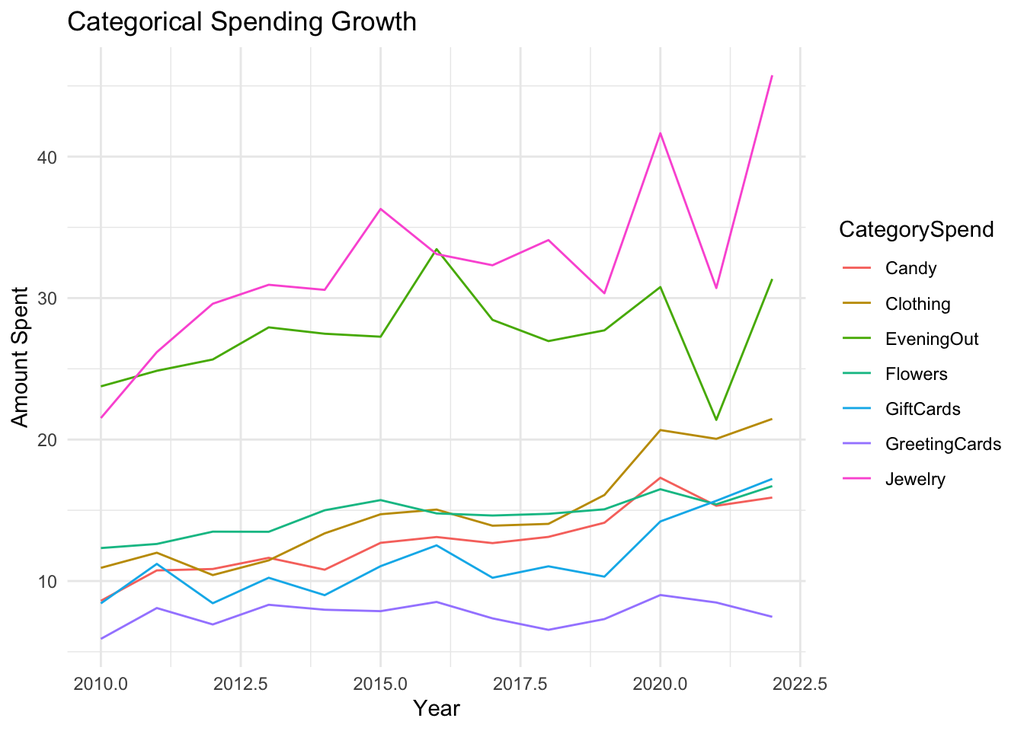

```r
ggplot(historical_spending_long, aes(x = Year, y = Spent, color = CategorySpend)) +
  geom_line() +
  labs(x = "Year", y = "Amount Spent", title = "Categorical Spending Growth") +

  theme_minimal()
```

Looks like greeting cards are a good hedge against inflation :)

I also want to explore the makeup at each age and what they spend their money on.

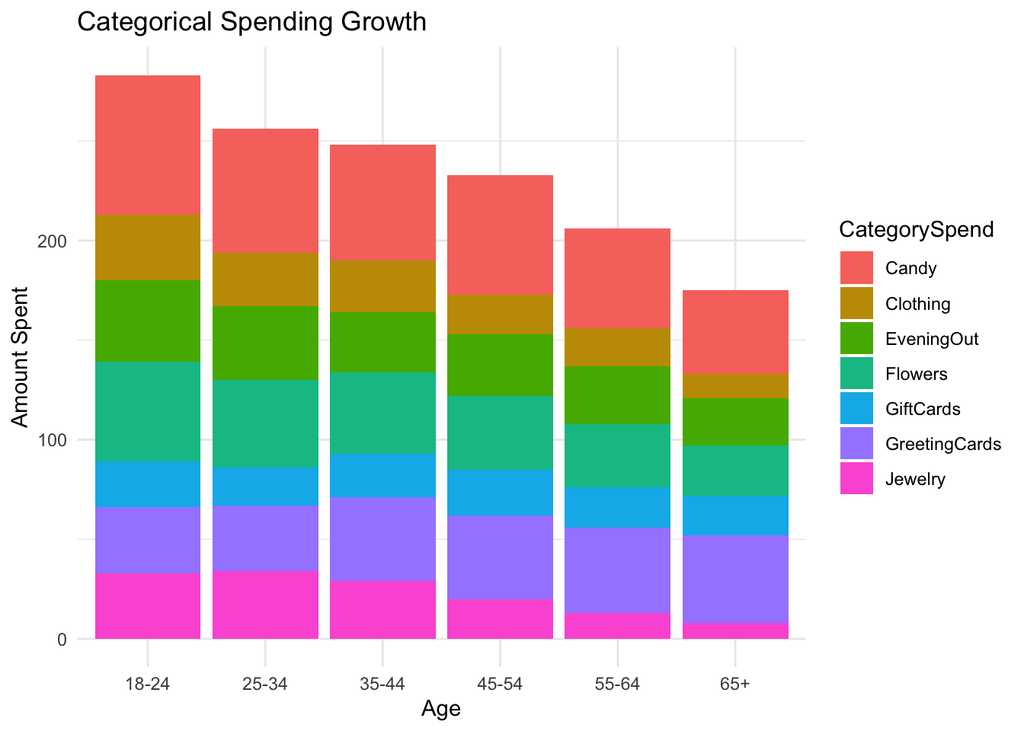

```r
age_spending_long <- pivot_longer(gifts_age, cols = c("Candy","Flowers","Jewelry","GreetingCards","EveningOut","Clothing","GiftCards"), names_to = "CategorySpend", values_to = "Spent")

ggplot(age_spending_long, aes(x = Age, y = Spent, fill = CategorySpend)) +
  geom_col() +
  labs(x = "Age", y = "Amount Spent", title = "Categorical Spending Growth") +
  theme_minimal()
```

Now lets see per person because there might be less 65 year olds in our sample

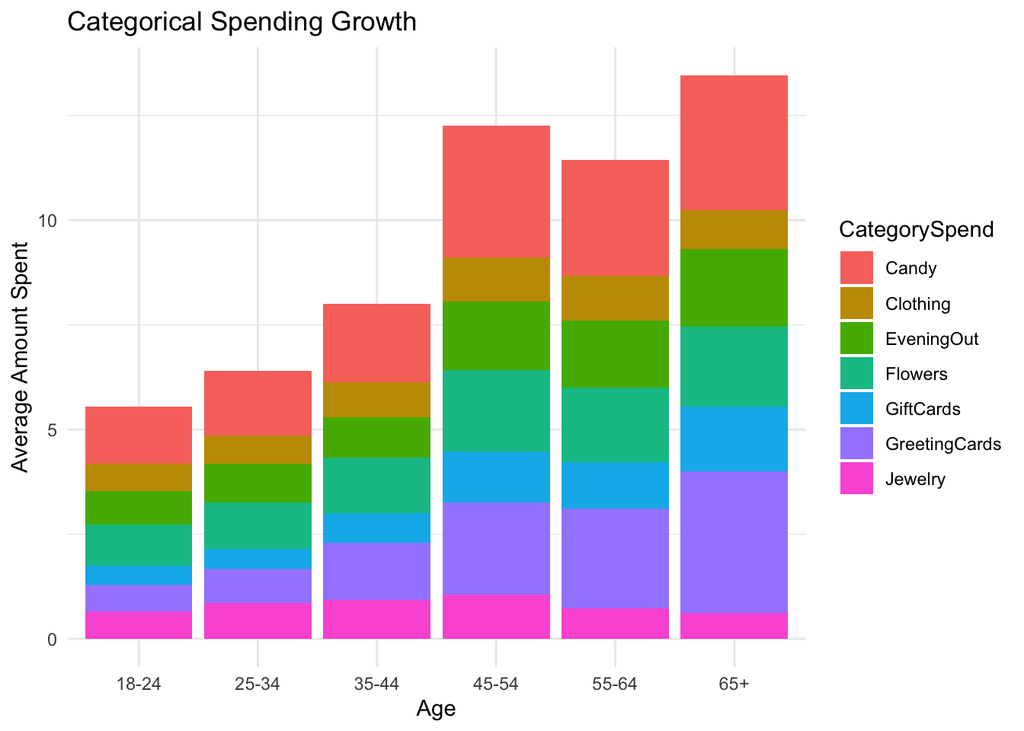

```r
age_spending_long <- pivot_longer(gifts_age, cols = c("Candy","Flowers","Jewelry","GreetingCards","EveningOut","Clothing","GiftCards"), names_to = "CategorySpend", values_to = "Spent")

ggplot(age_spending_long, aes(x = Age, y = Spent/SpendingCelebrating, fill = CategorySpend)) +
  geom_col() +
  labs(x = "Age", y = "Average Amount Spent", title = "Categorical Spending Growth") +
  theme_minimal()
```

Older people have more money to spend. Who woulda guessed!?!

Lets see the makup on a gendered basis

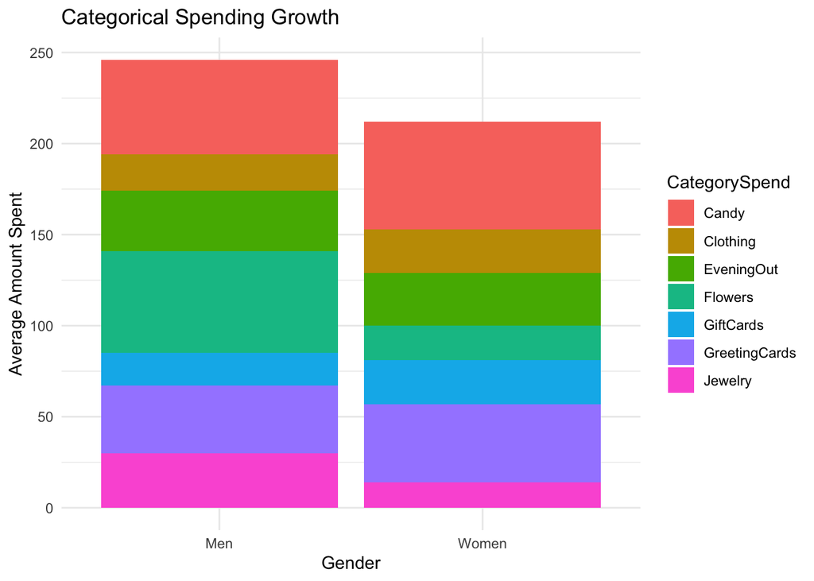

```r
gender_spending_long <- pivot_longer(gifts_gender, cols = c("Candy","Flowers","Jewelry","GreetingCards","EveningOut","Clothing","GiftCards"), names_to = "CategorySpend", values_to = "Spent")

ggplot(gender_spending_long, aes(x = Gender, y = Spent, fill = CategorySpend)) +
  geom_col() +
  labs(x = "Gender", y = "Average Amount Spent", title = "Categorical Spending Growth") +
  theme_minimal()
```

Men spend more total, and in a few key categories, especially Flowers.